# Lecture 04

## 2.3.0 Barplots stack our categorical data by proportion

Can we create a bar plot of embryos per infection dose? With `geom_bar()` and the proper `aes()` we can fill in colour along the bar to represent specific infection dates.

The default use of `geom_bar()` is to create a barchart where the height of each bar is the *sum* of the total number of observations (ie rows in embryos) for a particular group (ie infection dose level). The default argument for this calculation in `geom_bar()` is `stat="count"`.

Let’s go ahead and make a bar chart to count how many animals **N2** we have used in our experiments, categorizing those counts based on the **doseLevel** variable. We’ll `fill` the bar colours based on infection dates.

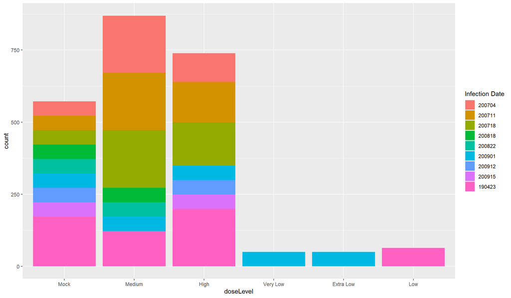

```r
# What happens if we don't specify an "identity" and y-axis value?

embryo_norm.df %>%
  # Filter for uninfected N2 observations
  filter(wormStrain == "N2") %>%

  # 1. Data
  ggplot(.) +
    # 2. Aesthetics
    aes(x=doseLevel, fill=`Infection Date`) +
    # 4. Geoms
    geom_bar()   ### 2.3.0 change it up to a barplot geom
```

### 2.3.1 Show normalized proportion of subgroups with `position_fill()`

As you can see above, the bar graphs show the total *observations* for each `Infection Date` across each `doseLevel`. If, however, you want to give a sense of overall proportion, you can bring all of the bars up to the same height by setting the `position` parameter to `position_fill()`.

This is helpful when trying to convey the percentage a subset of data represents within a grouping.

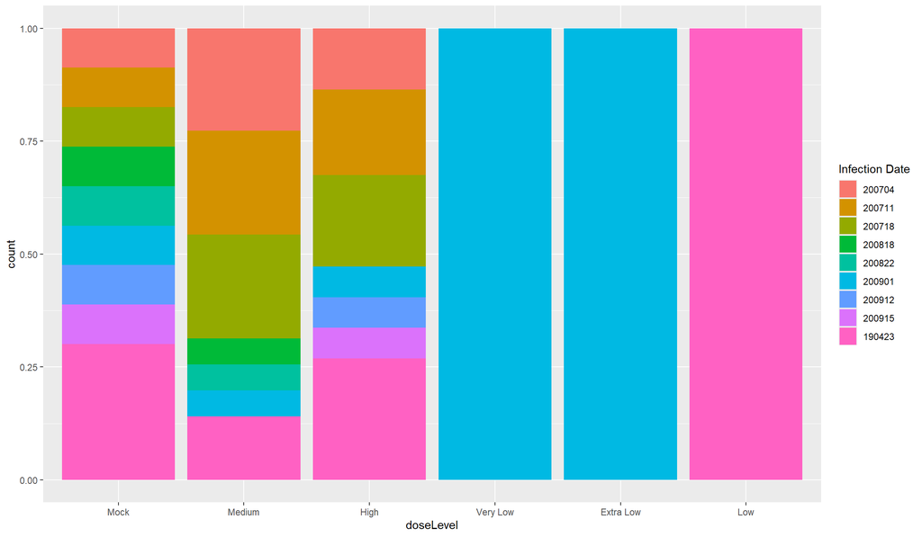

```r
# What happens if we don't specify an "identity" and y-axis value?

embryo_norm.df %>%
  # Filter for uninfected N2 observations
  filter(wormStrain == "N2") %>%

  # 1. Data
  ggplot(.) +
    # 2. Aesthetics
    aes(x=doseLevel, fill=`Infection Date`) +

    # 4. Geoms
    ### 2.3.1 set the position parameter to position_fill()
    geom_bar(position = position_fill())
```

**Normalized proportion vs absolute count:** Depending on the nature of your data, you may wish to display your stacked data by absolute count or by proportion. While our stacked barplot in section **2.3.0** clearly relays the size of our groups **AND** how subgroups such as replicates are distributed, it is a little harder to gauge the overall proportion of each replicate in each bar. On the other hand, by producing a normalized stacked barchart, we can now more accurately gauge the *proportions* of our subgroups **BUT** we sacrifice any knowledge of *group size* as a result.

### 2.3.2 Stack values of a variable *within* your `geom_bar()` using the `stat` parameter

Suppose we wanted to look at how the sum total of embryos was presented across our barcharts - ie how much do the actual observations contribute to total embryo values? In this case we are no longer looking at the number of observations but the *actual measurements from those observations*.

There are two ways to accomplish this. The first is to use `geom_bar()` to visualize the *sum of values* of a variable by using the `stat=identity` parameter instead but a `y` variable must be identified. Let’s show how that can be done.

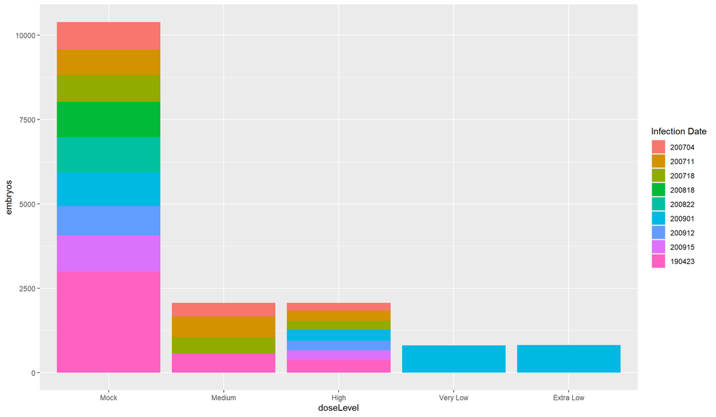

```r
# Make a bar graph based on embryo counts and fill by Infection Date

embryo_norm.df %>%
  # Filter for N2 observations regardless of infection status
  filter(wormStrain == "N2", (sporeStrain == "ERTm5" | doseLevel == "Mock")) %>%

  # 1. Data
  ggplot(.) +
    # 2. Aesthetics
    aes(x=doseLevel, y = embryos, fill=`Infection Date`) +

    # 4. Geoms
    geom_bar(stat = "identity")   ### 2.3.2 Sum the actual values from the y-axis
```

## 2.4.0 Use `geom_col()` to produce stacked bar charts of values

Both `geom_bar()` and `geom_col()` produce similar results but rather than changing the default behaviour of `geom_bar()`, if you want to produce a stacked barchart based on values, you should use the appropriate tool: `geom_col()`. The code is the same except we can use the default parameters to get the same behaviour as above.

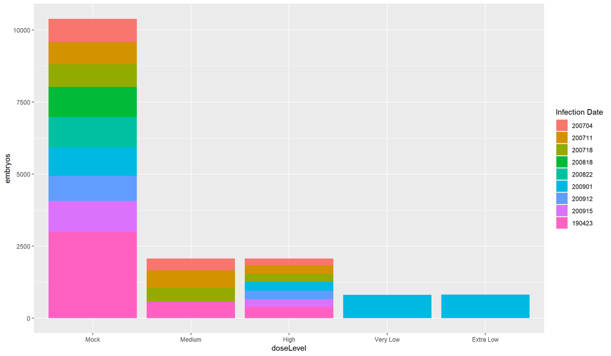

```r
# Make a bar graph based on embryo counts and fill by Infection Date

embryo_norm.df %>%
  # Filter for N2 observations regardless of infection status
  filter(wormStrain == "N2", (sporeStrain == "ERTm5" | doseLevel == "Mock")) %>%

  # 1. Data
  ggplot(.) +
    # 2. Aesthetics
    aes(x=doseLevel, y = embryos, fill=`Infection Date`) +

    # 4. Geoms
    geom_col()   ### 2.4.0 Use geom_col() instead to produce the stacked bar chart
```

So you can see we’ve generated the exact same output but with slightly less code.

### 2.4.1 Dodge your barplots with the `position` parameter

As with our histograms from section **2.2.0** we can choose to unstack our bars and display the categories individually. To do so, you can use the `position` parameter and set it with `position_dodge()` or `position_dodge2()`. Using this option will allow us to see each individual group but each will display a little differently.

Let’s start with `position_dodge()`.

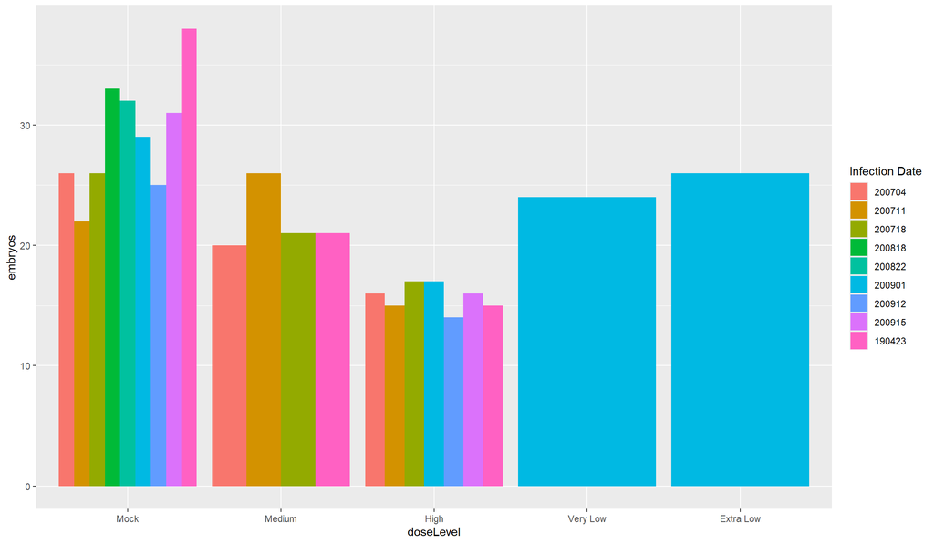

```r
# Make a bar graph based on embryo counts and fill by Infection Date

embryo_norm.df %>%
  # Filter for N2 observations regardless of infection status
  filter(wormStrain == "N2", (sporeStrain == "ERTm5" | doseLevel == "Mock")) %>%

  # 1. Data
  ggplot(.) +
    # 2. Aesthetics
    aes(x=doseLevel, y = embryos, fill=`Infection Date`) +

    # 4. Geoms
    geom_col(position = position_dodge())   ### 2.4.1 Use position_dodge()
```

Looking at the **Mock** category, we can see that the values don’t appear to sum up to anywhere near 10,000! So where did all of our data go? Looking closely at the bar graph now, it looks like we are only displaying the maximum value for each bar/category. While this appears to be the case, each observation within each group is actually being layered upon one another. Unfortunately, you cannot obtain a subgrouped stack of the values in this way.

Using the `position_dodge2()` option may help to show our data more distinctly. Let’s see if that works.

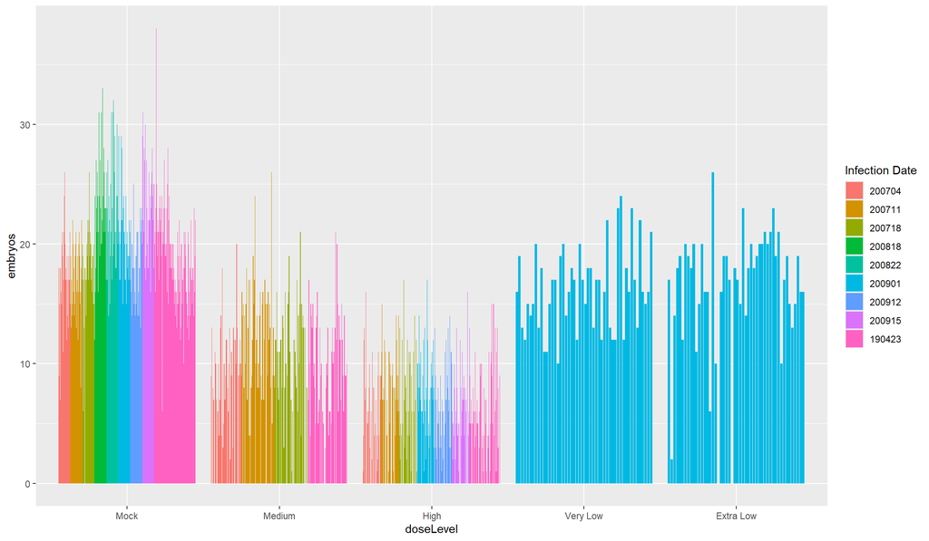

```r
# Make a bar graph based on embryo counts and fill by Infection Date

embryo_norm.df %>%
  # Filter for N2 observations regardless of infection status
  filter(wormStrain == "N2", (sporeStrain == "ERTm5" | doseLevel == "Mock")) %>%

  # 1. Data
  ggplot(.) +
    # 2. Aesthetics
    aes(x=doseLevel, y = embryos, fill=`Infection Date`) +

    # 4. Geoms
    geom_col(position = position_dodge2())   ### 2.4.1 Use position_dodge2() to properly view our data
```

We can see from our bar graph now that each observation is graphed as it’s own bar! If we wanted to dodge with stacked bars (ie using `position_dodge()`), we would need to use an aggregated set of data to combines observations within replicates.

**Comprehension Question 2.4.1:** How would we re-use our code from above to generate a dodged barplot where each each **Infection Date** is the stacked value of embryos across each **doseLevel**?

```r
# comprehension answer code 2.4.1
# Make a dodged bar graph based on total embryo counts and fill by Infection Date across doseLevels

embryo_norm.df %>%
  # Filter for N2 observations regardless of infection status
  filter(wormStrain == "N2", (sporeStrain == "ERTm5" | doseLevel == "Mock")) %>%
  # Group and summarize your data
  ... %>%
  ... %>%

  # 1. Data
  ggplot(.) +
    # 2. Aesthetics
    aes(x=doseLevel, y = totalEmb, fill=`Infection Date`) +
    # 4. Geoms
    geom_col(position = position_dodge2())
```

### 2.4.2 Flip your data to display horizontally with `coord_flip()`

Our data looks quite squished when displaying the bars vertically. You can have your bars run horizontally instead of vertically by using the `coord_flip()` layer. For this simplicity in this example, we’ll return to using `position_dodge()` even though we know it’s not quite a correct visualization of our data.

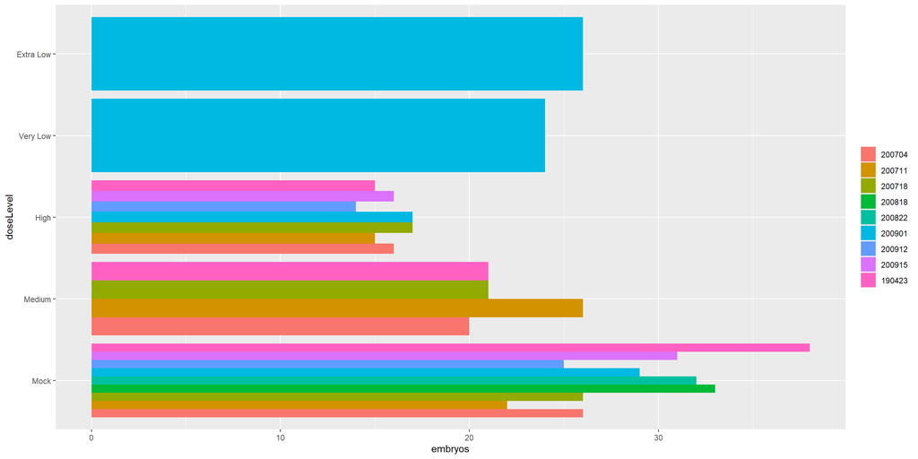

```r
# Make a bar graph based on embryo counts and fill by Infection Date

embryo_norm.df %>%
  # Filter for N2 observations regardless of infection status
  filter(wormStrain == "N2", (sporeStrain == "ERTm5" | doseLevel == "Mock")) %>%

  # 1. Data
  ggplot(.) +
    # 2. Aesthetics
    aes(x=doseLevel, y = embryos, fill=`Infection Date`) +
    theme(legend.title = element_blank()) + # Update the legend by removing the title

    # 4. Geoms
    geom_col(position = position_dodge()) + # Use position_dodge()

    # 7. Coordinates
    coord_flip()                            ### 2.4.2 Add a coord_flip() layer to our plot
```

### 2.4.3 Reorder your categorical x-axis with `fct_rev()`

Looks like our results aren’t quite what we wanted on that coordinate flip. If you would rather the vertical order of our categories start with “Mock” instead, you can use the `fct_rev()` function from the `forcats` package.

This is a simple function that does exactly what we think! It will alter the levels in a factor so that they are in reverse order. Recall that our `doseLevel` variable is also a factor. Reordering these our categorical axis would not be as easy if we had not already converted this variable into a factor!

**More ways to order your factors:** The **forcats** package of the tidyverse actually offers a number of functions that can help to reorder your data based on certain expectations. This can be extremely helpful when, for instance, trying to match your legend to coincide with the vertical order of lines on a linegraph. Check out more functions like **fct_reorder2()** over on the [tidyverse website.](https://forcats.tidyverse.org/index.html)

Let’s see how `fct_rev()` can affect our visualization.

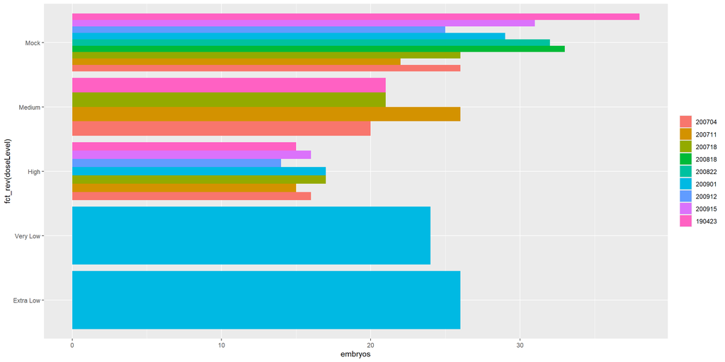

```r
# Make a bar graph based on embryo counts and fill by Infection Date

embryo_norm.df %>%
  # Filter for N2 observations regardless of infection status
  filter(wormStrain == "N2", (sporeStrain == "ERTm5" | doseLevel == "Mock")) %>%

  # 1. Data
  ggplot(.) +
    # 2. Aesthetics

    ### 2.4.3 Reorder your x-axis factor. This will become the y-axis!
    aes(x=fct_rev(doseLevel),
        y = embryos, fill=`Infection Date`) +
    theme(legend.title = element_blank()) +   # Update the legend by removing the title

    # 4. Geoms
    geom_col(position = position_dodge()) +   # Use position_dodge()

    # 7. Coordinates
    coord_flip()                              # Add a coord_flip() layer to our plot
```

## 2.5.0 Boxplots provide visual summary statistics of your data

Boxplots are a great way to visualize summary statistics for your data. As a reminder, the thick line in the center of the box is the **median**. The upper and lower ends of the box are the first and third **quartiles** (or 25th and 75th percentiles) of your data. The whiskers extend to the largest value no further than 1.5*IQR (inter-quartile range - the distance between the first and third quartiles).

Data beyond these whiskers are considered **outliers** and plotted as individual points. This is a quick way to see how comparable your samples or variables are.

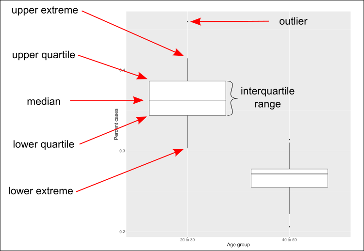

The dissection of a boxplot’s components shows us how it summarizes data distribution.

We are going to use boxplots to see the distribution of normalized embryos for N2 across different infections. For this analysis, we’ll actually filter our data *twice* in order to make sure we capture the values we want to show.

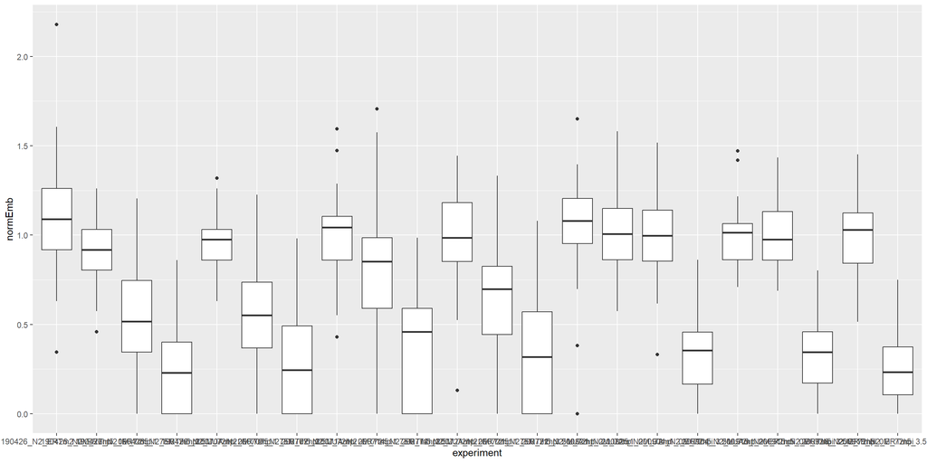

```r
# Let's make a basic boxplot with our embryo data
embryo_norm.df %>%
  # Filter for N2 observations for infection by ERTm5
  filter(wormStrain %in% c("N2"),
          # This will filter for N2/ERTm5 experiments or N2/untreated
         (sporeStrain == "ERTm5" | doseLevel == "Mock")) %>%

  # Filter again to just get 3 levels of infection
  filter(doseLevel %in% c("Mock", "Medium", "High")) %>%

  # 1. Data
  ggplot(.) +
    # 2. Aesthetics
    aes(x=experiment, y = normEmb) + # Break data up by experiment along the x-axis
    # 4. Geoms
    geom_boxplot()        ### 2.5.0 Switch over to a boxplot geom
```

### 2.5.1 Rotate axis text by updating `theme()` and `angle`

Oh no! We can immediately see there are some issues with the plot. Text along the x-axis is overlapping and illegible. Let’s fix the text on the x-axis by rotating it 90 degrees. To accomplish this we will use the `theme()` layer.

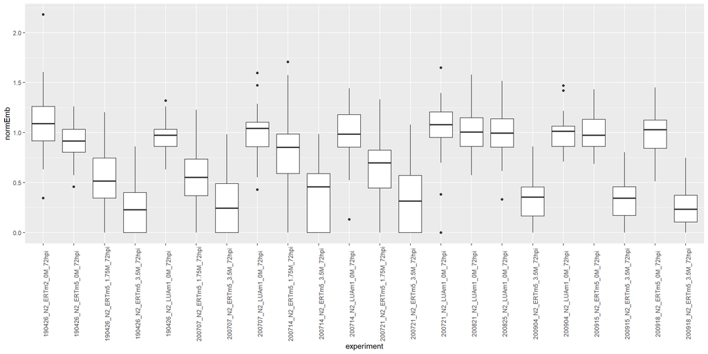

```r
# Access the theme of the plot and update the text angle

embryo_norm.df %>%
  # Filter for N2 observations for infection by ERTm5
  filter(wormStrain %in% c("N2"),
          # This will filter for N2/ERTm5 experiments or N2/untreated
         (sporeStrain == "ERTm5" | doseLevel == "Mock")) %>%

  # Filter again to just get 3 levels of infection
  filter(doseLevel %in% c("Mock", "Medium", "High")) %>%

  # 1. Data
  ggplot(.) +
    # 2. Aesthetics
    aes(x=experiment, y = normEmb) + # Break data up by experiment along the x-axis
    theme(axis.text.x = element_text(angle = 90)) +  ### 2.5.1 Rotate the x-axis text

    # 4. Geoms
    geom_boxplot()        # 2.5.0 Switch over to a boxplot geom
```

### 2.5.2 Justify the axis text through `theme()` and `hjust` or `vjust`

We’ve updated the angle of our text but they’re positioned on somewhat of a “centred” alignment. We can justify the labels such that they align with the x-axis. We will set two parameters in our figure:

- `hjust` - horizontal justification which ranges from 0 to 1 (0 = left, 1 = right)
- `vjust` - vertical justification which also ranges from 0 to 1 (0 = top, 1 = bottom)

In the case of our text, we are using the `hjust` to move the labels vertically towards the x-axis while the `vjust` parameter will help to center our text (horizontall) with the x-axis tick marks. If you look in the help menu at `element_text()` you will see that the justification is carried out *before* the rotation. While we can specify the parameters of `element_text()` in any order, this does not change the order of when they are executed in the function.

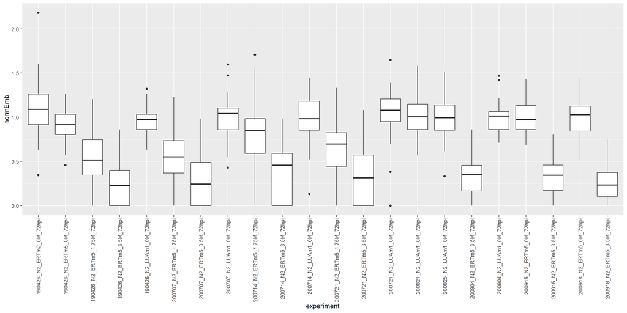

```r
# Update our plot to push our text to align with the x-axis

embryo_norm.df %>%
  # Filter for N2 observations for infection by ERTm5
  filter(wormStrain %in% c("N2"),
          # This will filter for N2/ERTm5 experiments or N2/untreated
         (sporeStrain == "ERTm5" | doseLevel == "Mock")) %>%

  # Filter again to just get 3 levels of infection
  filter(doseLevel %in% c("Mock", "Medium", "High")) %>%

  # 1. Data
  ggplot(.) +
    # 2. Aesthetics
    aes(x=experiment, y = normEmb) + # Break data up by experiment along the x-axis
    ### 2.5.2 Adjust the horizontal and vertical justification
    theme(axis.text.x = element_text(angle = 90, hjust = 1, vjust = 0.5)) +

    # 4. Geoms
    geom_boxplot()        # 2.5.0 Switch over to a boxplot geom
```

### 2.5.3 Slice your data to display what you’d like

Up until now, we’ve been doing some simple filtering on our data but you can really slice and subset your data for exactly what you’d like to display. In this case we’ll perform multiple filters to choose 2 specific worm strains, at the 72-hour timepoint and drop a number of infection dates that have incomplete data.

As long as you have a tibble at the end of your wrangling, you can try to plot it!

We’ll also play around with the aesthetic mapping to produce a *grouped box plot* by designating colour based on `doseLevel` and we will facet the plots between our 2 selected worms strains.

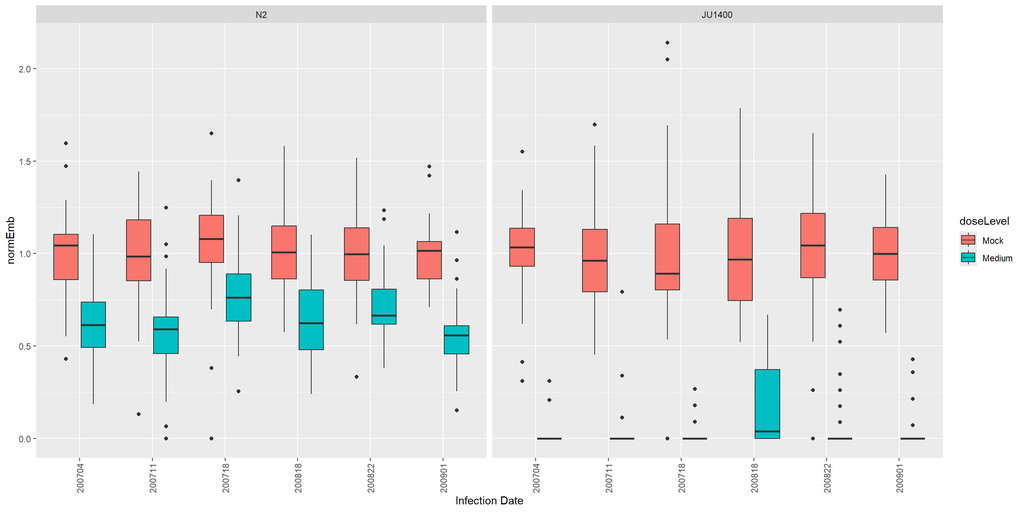

```r
# Update our plot to push our text to align with the x-axis

embryo_norm.df %>%
  ### 2.5.3 Filter for infections by LUAm1 over specific dates
  filter(wormStrain %in% c("N2", "JU1400"),
         expTimepoint == 72,
         # Drop these 3 replicate dates
         !`Infection Date` %in% c("200912", "200915", "190423"),
         (sporeStrain == "LUAm1" | doseLevel == "Mock")) %>%

  # Filter just for Mock or Medium infection
  filter(doseLevel %in% c("Mock", "Medium")) %>%

  # 1. Data
  ggplot(.) +
    # 2. Aesthetics
    ### 2.5.3 Plot by infection date and colour by doseLevel
    aes(x=`Infection Date`, y = normEmb, fill=doseLevel) +
    # Adjust the horizontal and vertical justification
    theme(axis.text.x = element_text(angle = 90, hjust = 1, vjust = 0.5)) +

    # 4. Geoms
    geom_boxplot() +        # 2.5.0 Switch over to a boxplot geom

    # 6. Facets
    facet_wrap(~wormStrain) # Facet output by worm strain
```

We will be using this graph as a base for customization later in the lesson.

## 2.6.0 Beeswarm Plots show all of your data points

Even though boxplots give us summary statistics on our data, it is useful to be able to see where our individual data points are. We’ve already used `geom_rug()` to help visualize our data distribution in density plots.

Similarly, for a boxplot we can add the data as a separate layer using `geom_point()` to place dots on top of our boxplot, or use `geom_jitter()` to spread our points out a bit. However, a **beeswarm plot** places data points that are overlapping (ie same value) next to each other instead of on top of each other, so we can get a better picture of the distribution of our data. We’ll start off by looking at the `geom_beeswarm()` function from the `ggbeeswarm` package.

We’ll subset our data to just 3 infection dates using N2 versus the ERTm5 spore strain. After generating the ggplot object, we’ll save it into a variable so we can update it later with `geom_beeswarm()` layer.

**Filter out those 0 values!** Remember how I just warned your about log transformations? The `ggbeeswarm()` package has some issues with -inf values so be sure to filter them out before trying to work with this kind of layer!

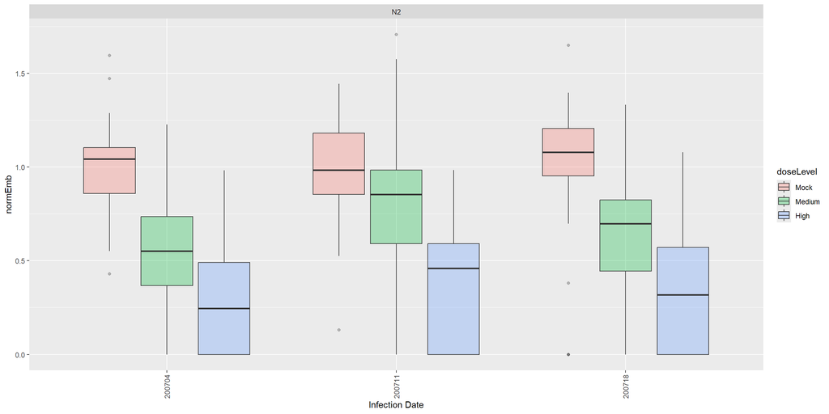

```r
# Save our boxplot object to a variable
boxplot <-

  embryo_norm.df %>%
  # Filter for infections by LUAm1 over specific dates
  filter(wormStrain %in% c("N2"),
         expTimepoint == 72,
         `Infection Date` %in% c("200704", "200711", "200718"),
         (sporeStrain == "ERTm5" | doseLevel == "Mock")) %>%

  filter(doseLevel %in% c("Mock", "Medium", "High")) %>%

  # 1. Data
  ggplot(.) +
    # 2. Aesthetics
    aes(x=`Infection Date`, y = normEmb, fill=doseLevel) + # Plot by infection date and colour by doseLevel

    ### 2.5.2 Adjust the horizontal and vertical justification
    theme(axis.text.x = element_text(angle = 90, hjust = 1, vjust = 0.5)) +

    # 4. Geoms
    geom_boxplot(alpha = 0.3) +        # 2.5.0 Switch over to a boxplot geom

    # 6. Facets
    facet_wrap(~wormStrain)

# Display the resulting boxplot
boxplot
```

### 2.6.1 Store `ggplot` objects as variables that you can continue to update

As you can see above, an option with `ggplot2` is to save your plot into a *ggplot object*. This works well if you know you are only changing one or two elements of your plot, and you do not want to keep retyping code. What we are going to vary here is how the data points are displayed.

Now, we can simply overlay the points with `geom_beeswarm()`. Notice that this `geom` comes from the `ggbeeswarm` package and is not a part of `ggplot2` itself. However, it was built to *work with* `ggplot2` objects!

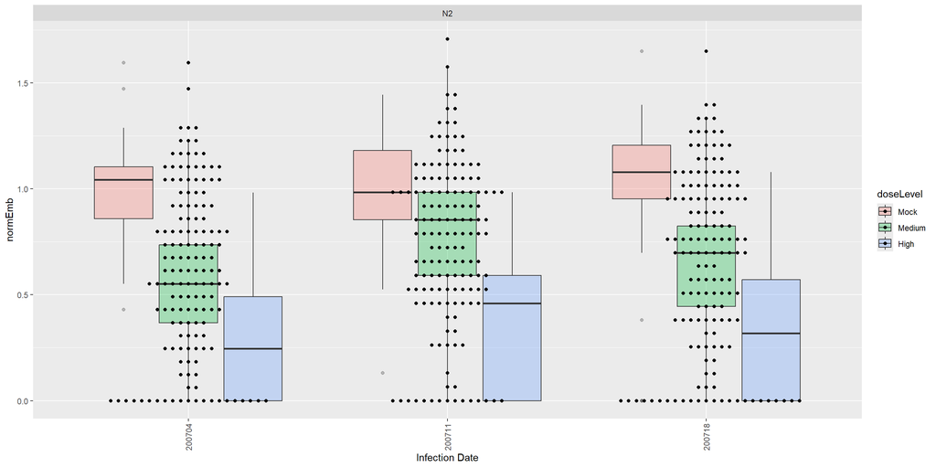

```r
# Load the ggbeeswarm package
library(ggbeeswarm)

# Add a geom to our saved plot
boxplot + geom_beeswarm()
```

Uh oh! What’s happened above here? As you can see, all our data points have been split by `Infection Date` but *not* subgrouped by the `doseLevel` variable. In order to plot our data in the correct subgroups, we’ll need to set the `dodge.width` parameter. You can think of this conceptually like dodging in our bar graphs.

Let’s set the `dodge.width` to 0.78 and see how that goes.

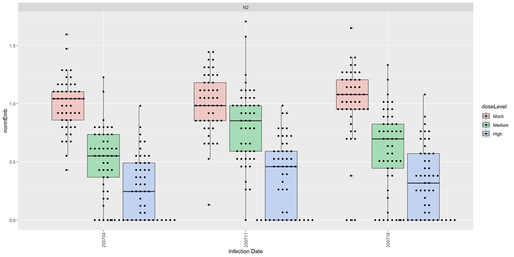

```r
# Update the dodge width to help separate our beeswarm plots

# Add a geom to our saved plot
boxplot + geom_beeswarm(dodge.width = 0.78)
```

### 2.6.2 `cex` is a common parameter used to adjust plotting properties of text and symbols

As you can see above, the spacing between points is quite even. Is there an way to change this spacing so the points are further apart?

Depending on the function or geom you may often find that the `cex` parameter can be adjusted to alter some aspect of how a geom or other graphical layer is displayed. In the case of `geom_beeswarm()` we can increase the spacing *between* data points to make its distribution a bit clearer.

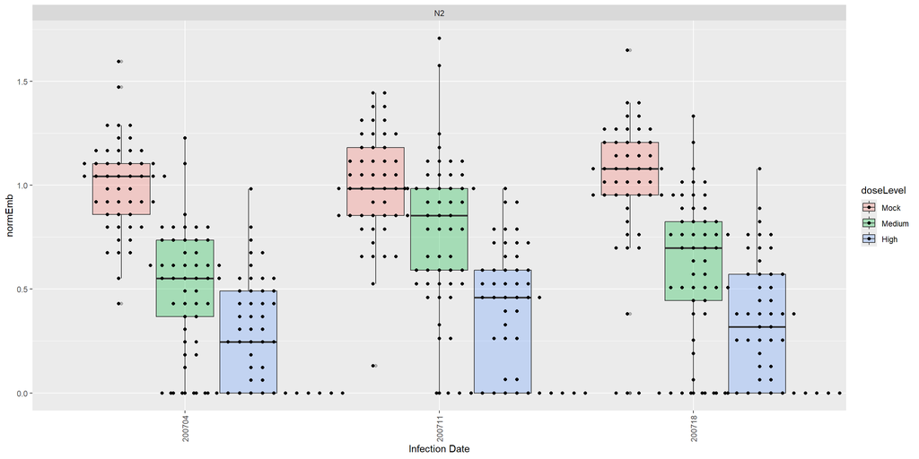

```r
# Update the cex parameter
boxplot + geom_beeswarm(dodge.width = 0.78, cex = 1.5)
```

Now, while it is nice to see all of our data points, it does appear quite crowded. We see problems especially at the lower area of the plot where there are observations with a value of 0. While we can guess at which grouping these belong to, we cannot know with absolulte certainty. For our audience, this is also a less than ideal presentation of these crowded data points.

### 2.6.3 Reduce overplotting with `geom_quasirandom()`

If you think you will have many points to display or if you want to avoid adjusting parameters with each new plot, consider using a `geom_quasirandom()` to give the empirical distribution of the stripplot to avoid overplotting. It is a geom included with the `ggbeeswarm` package and can simplify the look and creation of your plots. The distribution mirrors that of a KDE plot and the points are plotted within this theoretical space as a layer on top of your boxplot. We’ll include the `width` parameter to determine how widely each of our distributions are plotted.

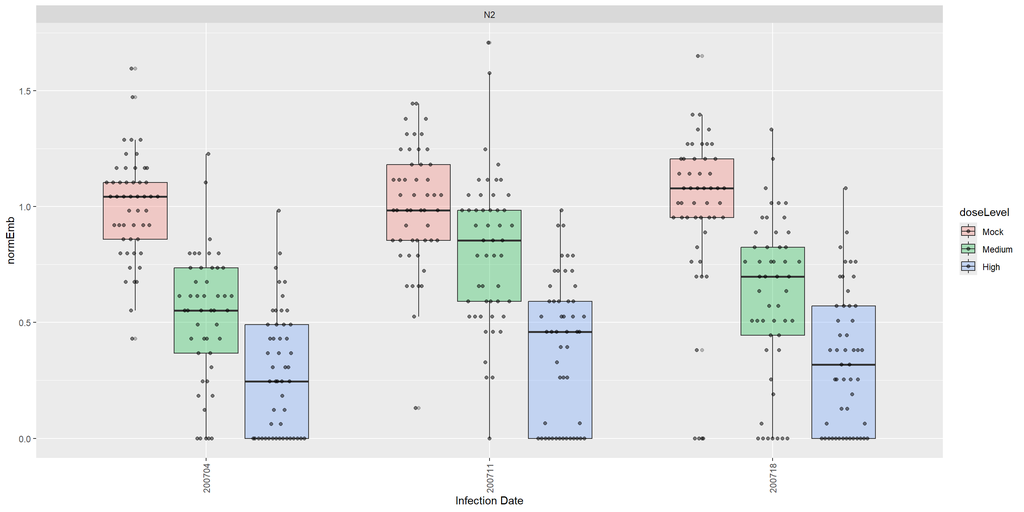

```r
# replace geom_beeswarm() with a geom_quasirandom()
boxplot + geom_quasirandom(dodge.width = 0.78,
                           width = 0.1,
                           alpha = 0.5) # Set the alpha to make overlapping points more visible
```

Other spacing and distribution options are available at https://github.com/eclarke/ggbeeswarm.

[figure not shown]

# 3.0.0 Customizing your plots

### 3.0.1 Attributes Related to Your Data

Up to this point, we’ve discussed some of the ways to alter our plots in ways to best visualize our data by dabbling with `colour`, `fill`, `shape`, and `position`. This has been accomplished mostly through the `aes()` attribute. Depending on the nature of the layers or elements you add, we can alter their characteristics individually to customize how they are displayed.

Plot elements relating to your data include things like axis labels, titles, colour or shapes that represent subsets of your data, scaling that is data-dependent, legends, and other data-driven parameters.

For customizing your data it is possible to change:

- `colour()`
- `fill()`
- `shape()`
- `size()`
- `alpha()`

Titles and axis labels can be added using:

- `ggtitle()`
- `xlab()`
- `ylab()`

We have seen in the above examples that colour can be applied to discrete or continuous variables. We can also use colour (shape, etc.) to represent outliers. In this dataset, outliers beyond the whiskers (above or below 1.5*IQR) can be coloured red.

Let’s update our base boxplot of from section **2.5.2** where we’ll make a new variable combining `Infection Date`, `sporeStrain`, and `doseLevel` to plot across the x-axis. We’ll also quickly update it to include some colour:

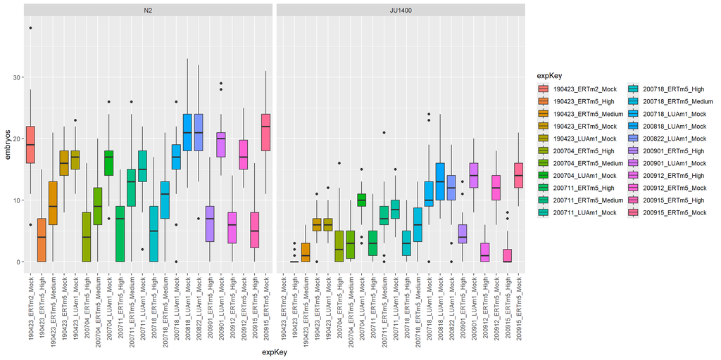

```r
# Update our plot to push our text to align with the x-axis

embryo_norm.df %>%
  # Filter for N2 observations to include infection by ERTm5 or any Mock infections
  filter(wormStrain %in% c("N2", "JU1400"),
         (sporeStrain == "ERTm5" | doseLevel == "Mock")) %>%
  filter(doseLevel %in% c("Mock", "Medium", "High")) %>%
  # We're going to make a new variable here that combines just Infection date, sporeStrain, and doseLevel
  unite(col = expKey, `Infection Date`, sporeStrain, doseLevel, sep = "_") %>%

  # 1. Data
  ggplot(.) +
    # 2. Aesthetics
    aes(x=expKey, y = embryos,
        fill = expKey) + ### 3.0.1 Update the fill colour using the experiment variable

    theme(axis.text.x = element_text(angle = 90, hjust = 1, vjust = 0.5)) +

    # 4. Geoms
    geom_boxplot() +

    # 6. Facets
    facet_wrap(~wormStrain) # Facet our data by worm strain
```

## 3.1.0 Adding a title and axis labels

Let’s start off by sprucing up our plot with

- `ggtitle()` to add a title to the plot.
- `ylab()` to rename and capitalize our variable name.
- `xlab()` to remove the “expKey” label from the plot. Note that I remove the x-axis label by using the keyword `NULL`.
- `guides()` to remove the legend from the right-hand side.

We’ll also update the boxplot outlier colour from black to red using the `outlier.colour` parameter in `geom_boxplot()`.

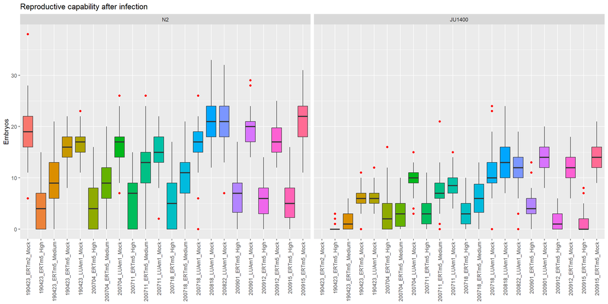

```r
# Update the various titles on our plot

embryo_norm.df %>%
  # Filter for N2 observations to include infection by ERTm5 or any Mock infections
  filter(wormStrain %in% c("N2", "JU1400"),
         (sporeStrain == "ERTm5" | doseLevel == "Mock")) %>%
  filter(doseLevel %in% c("Mock", "Medium", "High")) %>%
  # We're going to make a new variable here that combines just Infection date, sporeStrain, and doseLevel
  mutate(expKey = paste(`Infection Date`, sporeStrain, doseLevel, sep="_")) %>%

  # 1. Data
  ggplot(.) +
    # 2. Aesthetics
    aes(x=expKey, y = embryos,
        fill = expKey) + ### 3.0.1 Update the fill colour using the experiment variable

    theme(axis.text.x = element_text(angle = 90, hjust = 1, vjust = 0.5)) +

    ### 3.1.0 Update our titles and remove the legend
    ggtitle("Reproductive capability after infection") +
    xlab(NULL) +
    ylab("Embryos") +
    guides(fill="none") +

    # 4. Geoms
    geom_boxplot(outlier.colour = "red") + # Specify the colour of outliers

    # 6. Facets
    facet_wrap(~wormStrain) # Facet our data by worm strain
```

### 3.1.1 Use the `labs()` command to add multiple labels

Using individual commands to alter the x-, y-axis titles and the title of your plot can give you control over aspects of each individual element like font, size, and colour. If you want them to all have a uniform aesthetic (ie unaltered), you can simply use the `labs()` command to produce the text for each title. This layer can include legend titles too!

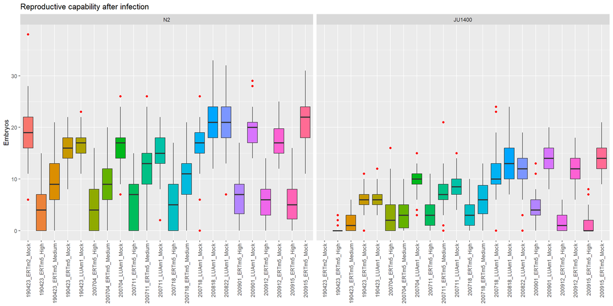

```r
# Update the various titles on our plot with labs()

embryo_norm.df %>%
  # Filter for N2 observations to include infection by ERTm5 or any Mock infections
  filter(wormStrain %in% c("N2", "JU1400"),
         (sporeStrain == "ERTm5" | doseLevel == "Mock")) %>%
  filter(doseLevel %in% c("Mock", "Medium", "High")) %>%
  # We're going to make a new variable here that combines just Infection date, sporeStrain, and doseLevel
  mutate(expKey = paste(`Infection Date`, sporeStrain, doseLevel, sep="_")) %>%

  # 1. Data
  ggplot(.) +
    # 2. Aesthetics
    aes(x=expKey, y = embryos,
        fill = expKey) + ### 3.0.1 Update the fill colour using the experiment variable

    theme(axis.text.x = element_text(angle = 90, hjust = 1, vjust = 0.5)) +

    # Update our titles and remove the legend
    ### 3.1.1 Use the labs() command to set all of your labels
    labs(title = "Reproductive capability after infection",
         x = NULL,
         y = "Embryos") +
    guides(fill="none") +

    # 4. Geoms
    geom_boxplot(outlier.colour = "red") + # Specify the colour of outliers

    # 6. Facets
    facet_wrap(~wormStrain) # Facet our data by worm strain
```

### 3.1.2 Assigning or altering labels on your plot

Looking at our strain labels for each facet, they are noticeably small and not necessarily self-explanatory. Let’s update the strain label values on these titles so they are more informative and update their themes to be more visible. This can be done in a couple of ways.

I am now going to save this plot in a *ggplot object*, since we are going to use this as our base plot for the next section.

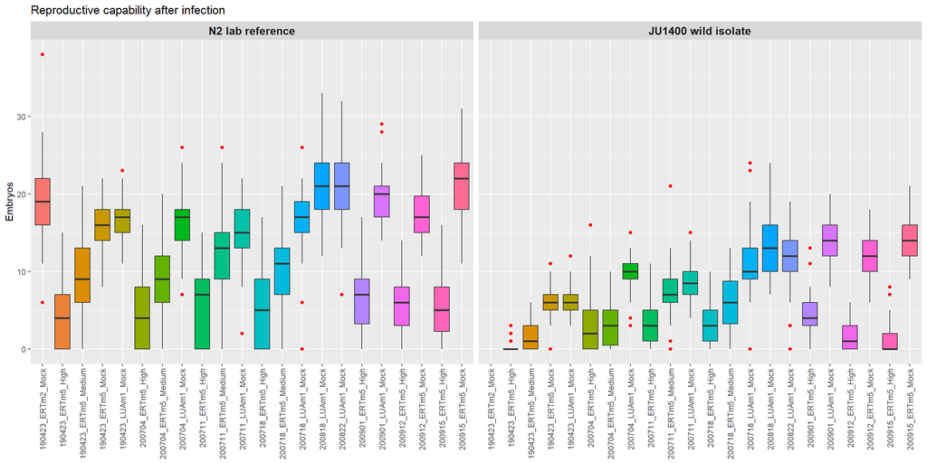

```r
# Make a named character vector for our labels
wormStrain_labels <- c(N2 = "N2 lab reference", JU1400 = "JU1400 wild isolate")

# Assign our plot to an object for alteration later on
my_plot <-

  embryo_norm.df %>%
  # Filter for N2 observations to include infection by ERTm5 or any Mock infections
  filter(wormStrain %in% c("N2", "JU1400"),
         (sporeStrain == "ERTm5" | doseLevel == "Mock")) %>%
  filter(doseLevel %in% c("Mock", "Medium", "High")) %>%
  # We're going to make a new variable here that combines just Infection date, sporeStrain, and doseLevel
  mutate(expKey = paste(`Infection Date`, sporeStrain, doseLevel, sep="_")) %>%

  # 1. Data
  ggplot(.) +
    # 2. Aesthetics
    aes(x=expKey, y = embryos,
        fill = expKey) + ### 3.0.1 Update the fill colour using the experiment variable

    theme(axis.text.x = element_text(angle = 90, hjust = 1, vjust = 0.5),
          ### 3.1.2 Update the facet title font
          strip.text.x = element_text(face = "bold", size = 12)
         ) +

    # Update our titles and remove the legend
    # Use the labs() command to set all of your labels
    labs(title = "Reproductive capability after infection",
         x = NULL,
         y = "Embryos") +
    guides(fill="none") +

    # 4. Geoms
    geom_boxplot(outlier.colour = "red") + # Specify the colour of outliers

    # 6. Facets
    facet_wrap(~wormStrain, labeller = labeller(wormStrain = wormStrain_labels)) ### 3.1.2 rename the worm strains

# display our plot
my_plot
```

## 3.2.0 Colour palettes!

[figure not shown]

A common custom modification is to change colours from `ggplot2`’s default rainbow palette. There are many reasons to change a colour palette including

- making it easier on the reader’s eye.
- making it colour-blind friendly.
- plots with continuous data should use good colour spectra for accurate representation.

Let’s create our own colour palette for each `experiment` in our boxplot.